# IMT paper: Bayes Factors

Thomas

7/27/2019

## Tim suggests using Bayes Factors on all so-called “null findings” to determine the evidence for the null.

### The primary outcome statistic is the correlation between predicted and observed IMT.

### Use the “BayesFactor” package to compute BF for each correlation and generate output.

### Follow steps in (https://richarddmorey.github.io/BayesFactor/#lincor)

### I don’t know how to interpret output - Tim and Javi, please help.

```r
library(BayesFactor)
library(ggplot2)
library(R.matlab)
library(sjPlot)
```

## OldFaces (PFA stimulus set) - wholebrain pattern

Load data:

```r
mat = readMat('~/Box/@Predict_IMT/Faces/OF/AllFaces/data.mat')
imt = data.frame(observed = mat$out[[7]], predicted = mat$out[[8]])
```

Replicate correlation and scatterplot:

```r
cor.test(imt$predicted, imt$observed)
```

```
##
##  Pearson's product-moment correlation
##
## data:  imt$predicted and imt$observed
## t = 2.7961, df = 425, p-value = 0.005407
## alternative hypothesis: true correlation is not equal to 0
## 95 percent confidence interval:
##  0.04001282 0.22641046
## sample estimates:
##       cor
## 0.1344003
```

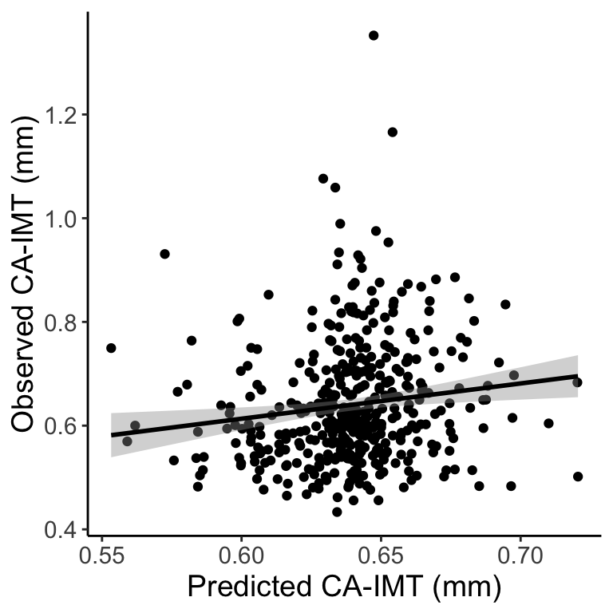

```r
ggplot(imt, aes(x = predicted, y = observed)) + geom_point() +
  geom_smooth(method = lm, colour = 'black') + theme_classic() +
  labs(x = "Predicted CA-IMT (mm)", y = "Observed CA-IMT (mm)") +
  theme(text = element_text(size = 14))
```

Compute BF as in (https://richarddmorey.github.io/BayesFactor/#lincor):

```r
bf = correlationBF(y = imt$observed, x = imt$predicted)
bf
```

```
## Bayes factor analysis
## --------------
## [1] Alt., r=0.333 : 5.158658 ±0%
##
## Against denominator:
##   Null, rho = 0
## ---
## Bayes factor type: BFcorrelation, Jeffreys-beta*
```

```r
samples = posterior(bf, iterations = 10000)
```

```
## Independent-candidate M-H acceptance rate: 98%
```

```r
summary(samples)
```

```
##
## Iterations = 1:10000
## Thinning interval = 1
## Number of chains = 1
## Sample size per chain = 10000
##
## 1. Empirical mean and standard deviation for each variable,
##    plus standard error of the mean:
##
##        Mean      SD  Naive SE Time-series SE
## rho  0.1324 0.04706 0.0004706      0.0004587
## zeta 0.1335 0.04802 0.0004802      0.0004676
##
## 2. Quantiles for each variable:
##
##         2.5%    25%    50%    75%  97.5%
## rho  0.03946 0.1003 0.1324 0.1639 0.2233
## zeta 0.03948 0.1007 0.1331 0.1654 0.2272
```

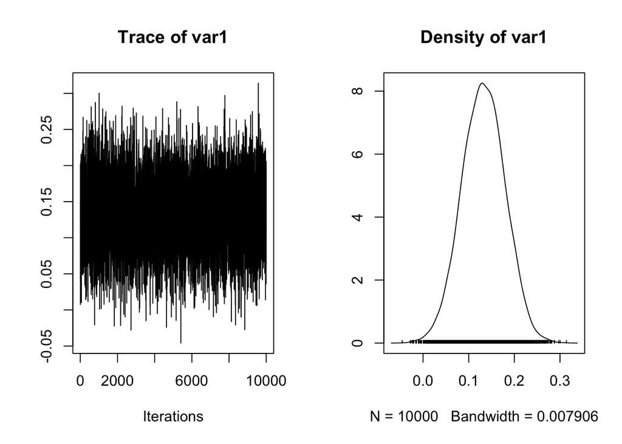

```r
plot(samples[,"rho"])
```

## OldFaces (PFA stimulus set) - amygdala ROI

Load data:

```r
mat = readMat('~/Box/@Predict_IMT/Faces/OF/AllFaces/amygdala/data.mat')
imt = data.frame(observed = mat$out[[7]], predicted = mat$out[[8]])
```

Replicate correlation and scatterplot:

```r
cor.test(imt$predicted, imt$observed)
```

```
##
##  Pearson's product-moment correlation
##
## data:  imt$predicted and imt$observed
## t = 2.0227, df = 425, p-value = 0.04373
## alternative hypothesis: true correlation is not equal to 0
## 95 percent confidence interval:
##  0.002774946 0.190777087
## sample estimates:
##        cor
## 0.09764708
```

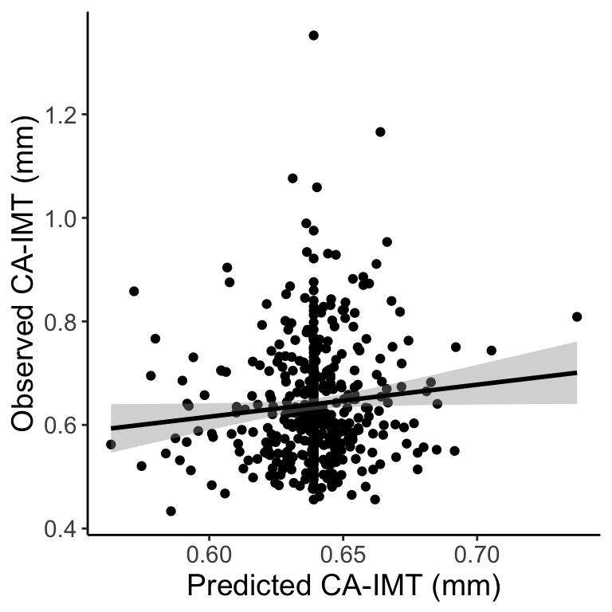

```r
ggplot(imt, aes(x = predicted, y = observed)) + geom_point() +
  geom_smooth(method = lm, colour = 'black') + theme_classic() +
  labs(x = "Predicted CA-IMT (mm)", y = "Observed CA-IMT (mm)") +
  theme(text = element_text(size = 14))
```

Compute BF as in (https://richarddmorey.github.io/BayesFactor/#lincor):

```r
bf = correlationBF(y = imt$observed, x = imt$predicted)
bf
```

```
## Bayes factor analysis
## --------------
## [1] Alt., r=0.333 : 0.8423685 ±0%
##
## Against denominator:
##   Null, rho = 0
## ---
## Bayes factor type: BFcorrelation, Jeffreys-beta*
```

```r
samples = posterior(bf, iterations = 10000)
```

```
## Independent-candidate M-H acceptance rate: 98%
```

```r
summary(samples)
```

```
##
## Iterations = 1:10000
## Thinning interval = 1
## Number of chains = 1
## Sample size per chain = 10000
##
## 1. Empirical mean and standard deviation for each variable,
##    plus standard error of the mean:
##
##         Mean      SD  Naive SE Time-series SE
## rho  0.09566 0.04723 0.0004723      0.0005039
## zeta 0.09617 0.04777 0.0004777      0.0005098
##
## 2. Quantiles for each variable:
##
##          2.5%     25%     50%    75%  97.5%
## rho  0.002387 0.06376 0.09624 0.1282 0.1869
## zeta 0.002387 0.06385 0.09654 0.1289 0.1892
```

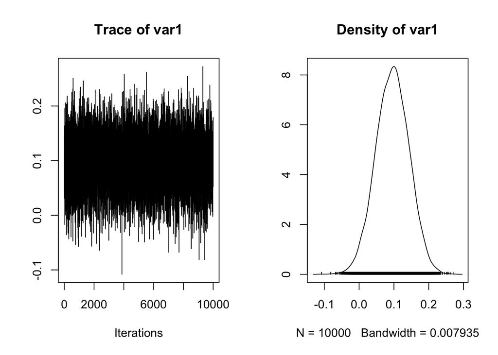

```r
plot(samples[,"rho"])
```

## OldFaces (PFA stimulus set) - amygdala lesion

Load data:

```r
mat = readMat('~/Box/@Predict_IMT/Faces/OF/AllFaces/amygdala_lesion/data.mat')
imt = data.frame(observed = mat$out[[7]], predicted = mat$out[[8]])
```

Replicate correlation and scatterplot:

```r
cor.test(imt$predicted, imt$observed)
```

```
##
##  Pearson's product-moment correlation
##
## data:  imt$predicted and imt$observed
## t = 2.7155, df = 425, p-value = 0.006887
## alternative hypothesis: true correlation is not equal to 0
## 95 percent confidence interval:
##  0.03614449 0.22273189
## sample estimates:
##       cor
## 0.1305944
```

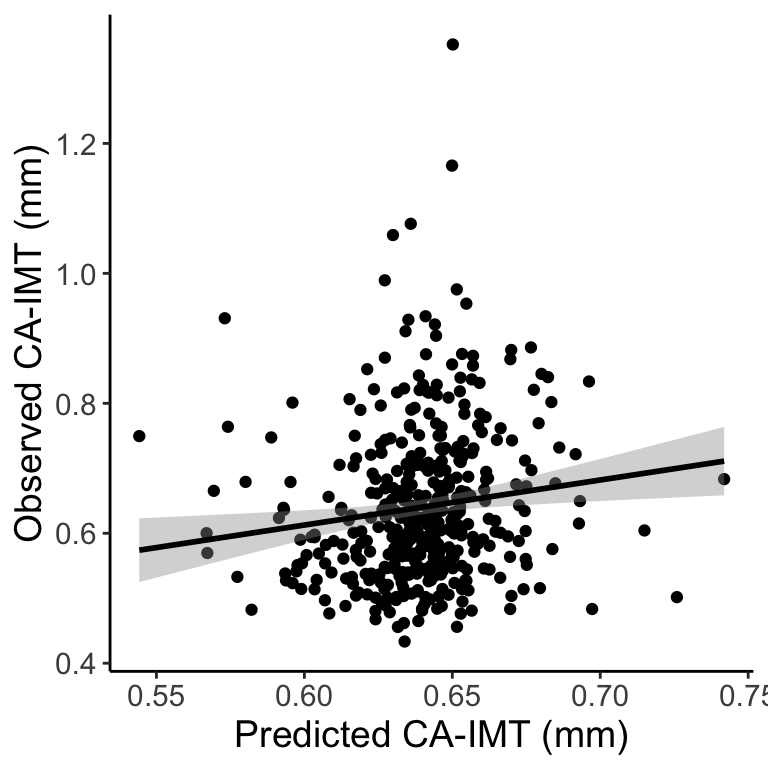

```r
ggplot(imt, aes(x = predicted, y = observed)) + geom_point() +
  geom_smooth(method = lm, colour = 'black') + theme_classic() +
  labs(x = "Predicted CA-IMT (mm)", y = "Observed CA-IMT (mm)") +
  theme(text = element_text(size = 14))
```

Compute BF as in (https://richarddmorey.github.io/BayesFactor/#lincor):

```r
bf = correlationBF(y = imt$observed, x = imt$predicted)
bf
```

```
## Bayes factor analysis
## --------------
## [1] Alt., r=0.333 : 4.16015 ±0%
##
## Against denominator:
##   Null, rho = 0
## ---
## Bayes factor type: BFcorrelation, Jeffreys-beta*
```

```r
samples = posterior(bf, iterations = 10000)
```

```
## Independent-candidate M-H acceptance rate: 98%
```

```r
summary(samples)
```

```
##
## Iterations = 1:10000
## Thinning interval = 1
## Number of chains = 1
## Sample size per chain = 10000
##
## 1. Empirical mean and standard deviation for each variable,
##    plus standard error of the mean:
##
##        Mean      SD  Naive SE Time-series SE
## rho  0.1285 0.04715 0.0004715      0.0005145
## zeta 0.1295 0.04805 0.0004805      0.0005242
##
## 2. Quantiles for each variable:
##
##         2.5%     25%    50%    75%  97.5%
## rho  0.03349 0.09721 0.1292 0.1598 0.2208
## zeta 0.03350 0.09752 0.1300 0.1612 0.2245
```

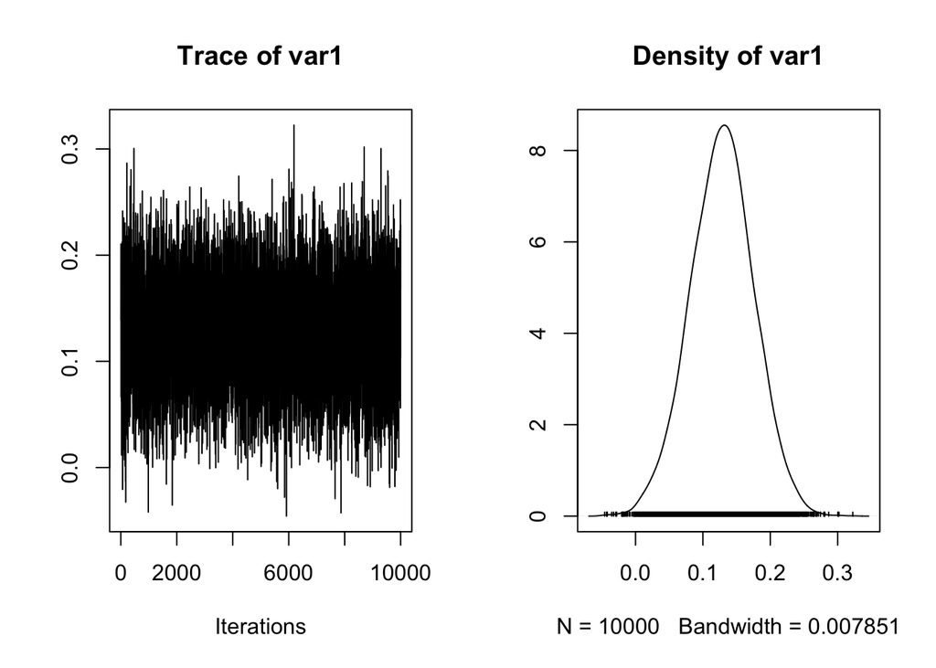

```r
plot(samples[,"rho"])
```

## OldFaces - PINES

Load data:

```r
imt = read.csv('~/Box/@Predict_IMT/Generalizability/predicted_observed_pattern-PINES_contrasts-OF.csv')
colnames(imt) = c('predicted', 'observed')
```

Replicate correlation and scatterplot:

```r
cor.test(imt$predicted, imt$observed)
```

```
##
##  Pearson's product-moment correlation
##
## data:  imt$predicted and imt$observed
## t = -1.2239, df = 425, p-value = 0.2217
## alternative hypothesis: true correlation is not equal to 0
## 95 percent confidence interval:
##  -0.15330031  0.03583474
## sample estimates:
##         cor
## -0.05926464
```

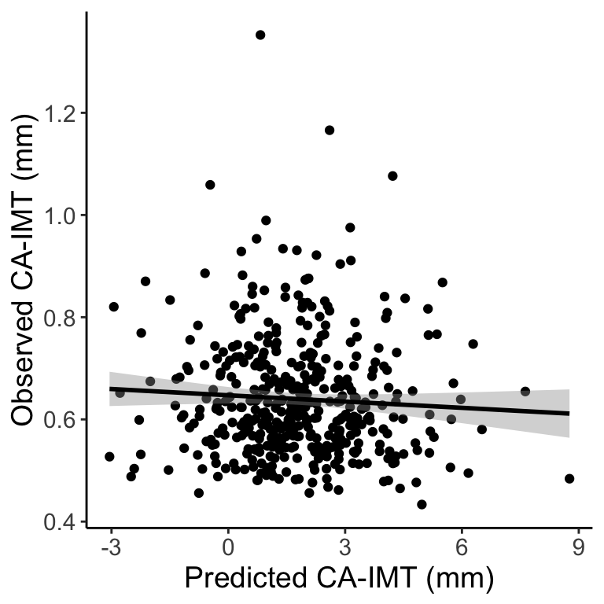

```r
ggplot(imt, aes(x = predicted, y = observed)) + geom_point() +
  geom_smooth(method = lm, colour = 'black') + theme_classic() +
  labs(x = "Predicted CA-IMT (mm)", y = "Observed CA-IMT (mm)") +
  theme(text = element_text(size = 14))
```

Compute BF as in (https://richarddmorey.github.io/BayesFactor/#lincor):

```r
bf = correlationBF(y = imt$observed, x = imt$predicted)
bf
```

```
## Bayes factor analysis
## --------------
## [1] Alt., r=0.333 : 0.2364748 ±0%
##
## Against denominator:
##   Null, rho = 0
## ---
## Bayes factor type: BFcorrelation, Jeffreys-beta*
```

```r
samples = posterior(bf, iterations = 10000)
```

```
## Independent-candidate M-H acceptance rate: 99%
```

```r
summary(samples)
```

```
##
## Iterations = 1:10000
## Thinning interval = 1
## Number of chains = 1
## Sample size per chain = 10000
##
## 1. Empirical mean and standard deviation for each variable,
##    plus standard error of the mean:
##
##          Mean      SD  Naive SE Time-series SE
## rho  -0.05804 0.04752 0.0004752      0.0004752
## zeta -0.05823 0.04779 0.0004779      0.0004779
##
## 2. Quantiles for each variable:
##
##         2.5%      25%      50%      75%   97.5%
## rho  -0.1501 -0.09029 -0.05813 -0.02663 0.03578
## zeta -0.1512 -0.09054 -0.05820 -0.02663 0.03579
```

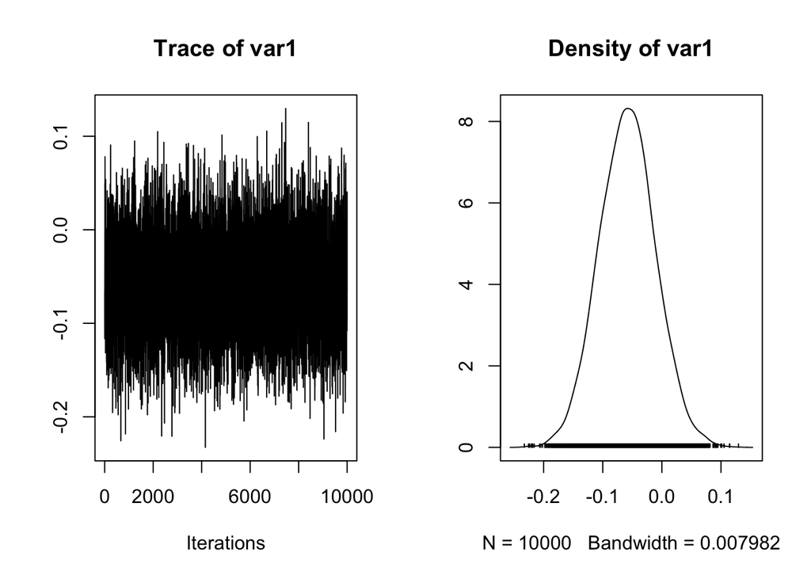

```r
plot(samples[,"rho"])
```

## NewFaces (NIM-STIM stimulus set) - wholebrain pattern

Load data:

```r
mat = readMat('~/Box/@Predict_IMT/Faces/NF/AllFaces/data.mat')
imt = data.frame(observed = mat$out[[7]], predicted = mat$out[[8]])
```

Replicate correlation and scatterplot:

```r
cor.test(imt$predicted, imt$observed)
```

```
##
##  Pearson's product-moment correlation
##
## data:  imt$predicted and imt$observed
## t = 0.92698, df = 448, p-value = 0.3544
## alternative hypothesis: true correlation is not equal to 0
## 95 percent confidence interval:
##  -0.04888239  0.13564363
## sample estimates:
##        cor
## 0.04375378
```

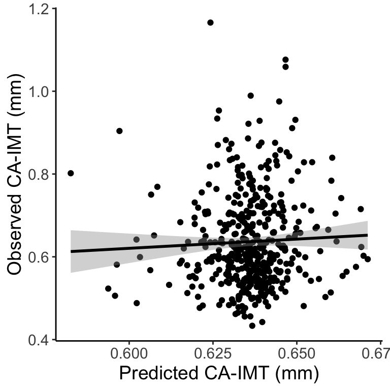

```r
ggplot(imt, aes(x = predicted, y = observed)) + geom_point() +
  geom_smooth(method = lm, colour = 'black') + theme_classic() +
  labs(x = "Predicted CA-IMT (mm)", y = "Observed CA-IMT (mm)") +
  theme(text = element_text(size = 14))
```

Compute BF as in (https://richarddmorey.github.io/BayesFactor/#lincor):

```r
bf = correlationBF(y = imt$observed, x = imt$predicted)
bf
```

```
## Bayes factor analysis
## --------------
## [1] Alt., r=0.333 : 0.1683669 ±0%
##
## Against denominator:
##   Null, rho = 0
## ---
## Bayes factor type: BFcorrelation, Jeffreys-beta*
```

```r
samples = posterior(bf, iterations = 10000)
```

```
## Independent-candidate M-H acceptance rate: 99%
```

```r
summary(samples)
```

```
##
## Iterations = 1:10000
## Thinning interval = 1
## Number of chains = 1
## Sample size per chain = 10000
##
## 1. Empirical mean and standard deviation for each variable,
##    plus standard error of the mean:
##
##         Mean      SD  Naive SE Time-series SE
## rho  0.04300 0.04680 0.0004680      0.0004680
## zeta 0.04312 0.04699 0.0004699      0.0004699
##
## 2. Quantiles for each variable:
##
##          2.5%     25%     50%     75%  97.5%
## rho  -0.04880 0.01139 0.04325 0.07461 0.1350
## zeta -0.04884 0.01139 0.04327 0.07475 0.1358
```

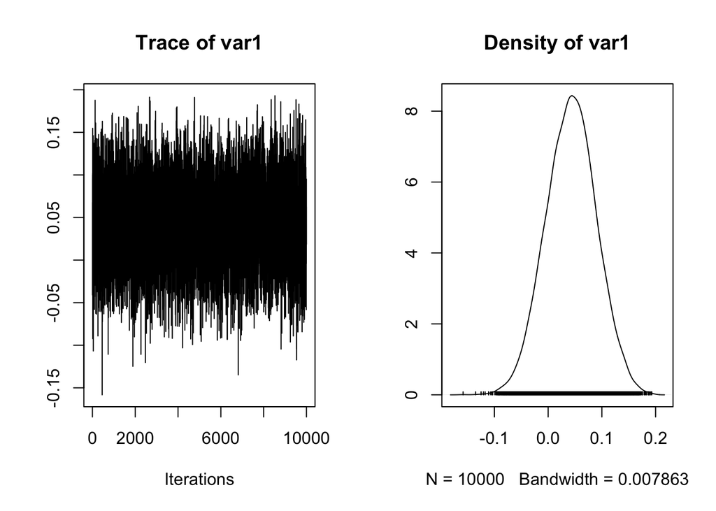

```r
plot(samples[,"rho"])
```

### Did not look at NewFaces amygdala ROI / amygdala lesion because the wholebrain pattern did not sufficiently predict IMT.

## IAPS - wholebrain pattern

Load data:

```r
mat = readMat('~/Box/@Predict_IMT/IAPS/data.mat')
imt = data.frame(observed = mat$out[[7]], predicted = mat$out[[8]])
```

Replicate correlation and scatterplot:

```r
cor.test(imt$predicted, imt$observed)
```

```
##
##  Pearson's product-moment correlation
##
## data:  imt$predicted and imt$observed
## t = 3.5015, df = 336, p-value = 0.0005252
## alternative hypothesis: true correlation is not equal to 0
## 95 percent confidence interval:
##  0.08260482 0.28853000
## sample estimates:
##       cor
## 0.1876283
```

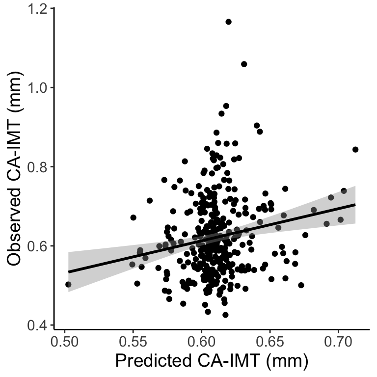

```r
ggplot(imt, aes(x = predicted, y = observed)) + geom_point() +
  geom_smooth(method = lm, colour = 'black') + theme_classic() +
  labs(x = "Predicted CA-IMT (mm)", y = "Observed CA-IMT (mm)") +
  theme(text = element_text(size = 14))
```

Compute BF as in (https://richarddmorey.github.io/BayesFactor/#lincor):

```r
bf = correlationBF(y = imt$observed, x = imt$predicted)
bf
```

```
## Bayes factor analysis
## --------------
## [1] Alt., r=0.333 : 47.09677 ±0%
##
## Against denominator:
##   Null, rho = 0
## ---
## Bayes factor type: BFcorrelation, Jeffreys-beta*
```

```r
samples = posterior(bf, iterations = 10000)
```

```
## Independent-candidate M-H acceptance rate: 96%
```

```r
summary(samples)
```

```
##
## Iterations = 1:10000
## Thinning interval = 1
## Number of chains = 1
## Sample size per chain = 10000
##
## 1. Empirical mean and standard deviation for each variable,
##    plus standard error of the mean:
##
##        Mean      SD  Naive SE Time-series SE
## rho  0.1835 0.05196 0.0005196      0.0005389
## zeta 0.1862 0.05393 0.0005393      0.0005592
##
## 2. Quantiles for each variable:
##
##         2.5%    25%    50%    75%  97.5%
## rho  0.07927 0.1492 0.1836 0.2190 0.2840
## zeta 0.07944 0.1503 0.1857 0.2226 0.2921
```

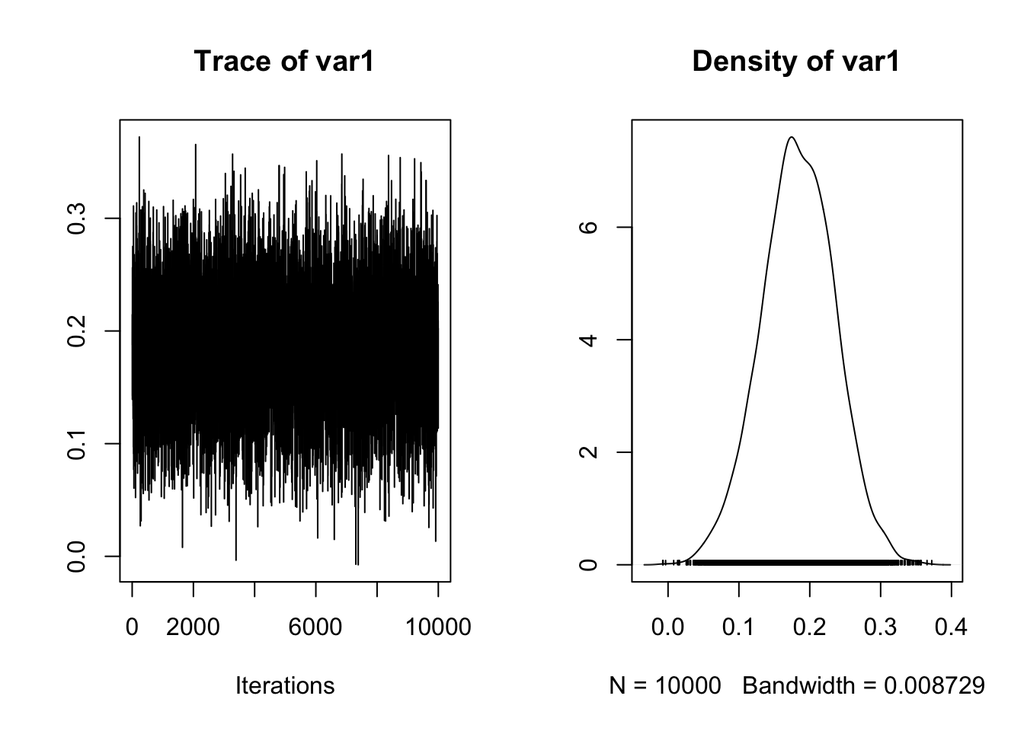

```r
plot(samples[,"rho"])
```

## IAPS - amygdala ROI

**NOTE** this produces a misleadingly strong negative correlation due to failure to generate a pattern (i.e., LASSO shrinks all predictors) in 1 of the 2 outer folds.

Load data:

```r
mat = readMat('~/Box/@Predict_IMT/IAPS/amygdala/data.mat')
imt = data.frame(observed = mat$out[[7]], predicted = mat$out[[8]])
```

Replicate correlation and scatterplot:

```r
cor.test(imt$predicted, imt$observed)
```

```
##
##  Pearson's product-moment correlation
##
## data:  imt$predicted and imt$observed
## t = -2.4031, df = 336, p-value = 0.0168
## alternative hypothesis: true correlation is not equal to 0
## 95 percent confidence interval:
##  -0.23342676 -0.02363771
## sample estimates:
##        cor
## -0.1299868
```

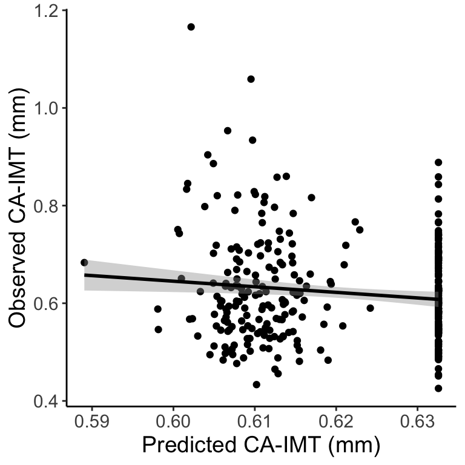

```r
ggplot(imt, aes(x = predicted, y = observed)) + geom_point() +
  geom_smooth(method = lm, colour = 'black') + theme_classic() +
  labs(x = "Predicted CA-IMT (mm)", y = "Observed CA-IMT (mm)") +
  theme(text = element_text(size = 14))
```

Compute BF as in (https://richarddmorey.github.io/BayesFactor/#lincor):

```r
bf = correlationBF(y = imt$observed, x = imt$predicted)
bf
```

```
## Bayes factor analysis
## --------------
## [1] Alt., r=0.333 : 2.115353 ±0%
##
## Against denominator:
##   Null, rho = 0
## ---
## Bayes factor type: BFcorrelation, Jeffreys-beta*
```

```r
samples = posterior(bf, iterations = 10000)
```

```
## Independent-candidate M-H acceptance rate: 97%
```

```r
summary(samples)
```

```
##
## Iterations = 1:10000
## Thinning interval = 1
## Number of chains = 1
## Sample size per chain = 10000
##
## 1. Empirical mean and standard deviation for each variable,
##    plus standard error of the mean:
##
##         Mean      SD  Naive SE Time-series SE
## rho  -0.1274 0.05400 0.0005400      0.0005618
## zeta -0.1285 0.05504 0.0005504      0.0005720
##
## 2. Quantiles for each variable:
##
##         2.5%     25%     50%      75%   97.5%
## rho  -0.2328 -0.1638 -0.1285 -0.09123 -0.0179
## zeta -0.2371 -0.1653 -0.1292 -0.09148 -0.0179
```

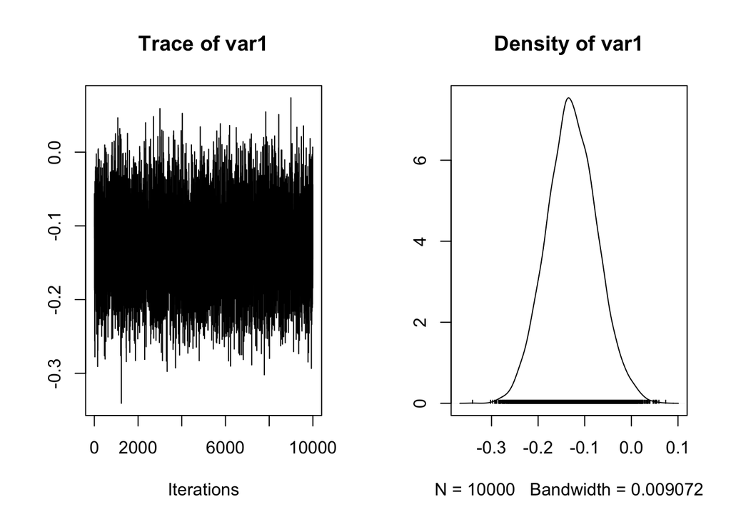

```r
plot(samples[,"rho"])
```

## IAPS - amygdala lesion

Load data:

```r
mat = readMat('~/Box/@Predict_IMT/IAPS/amygdala_lesion/data.mat')
imt = data.frame(observed = mat$out[[7]], predicted = mat$out[[8]])
```

Replicate correlation and scatterplot:

```r
cor.test(imt$predicted, imt$observed)
```

```
##
##  Pearson's product-moment correlation
##
## data:  imt$predicted and imt$observed
## t = 3.4924, df = 336, p-value = 0.0005427
## alternative hypothesis: true correlation is not equal to 0
## 95 percent confidence interval:
##  0.08212299 0.28808519
## sample estimates:
##       cor
## 0.1871602
```

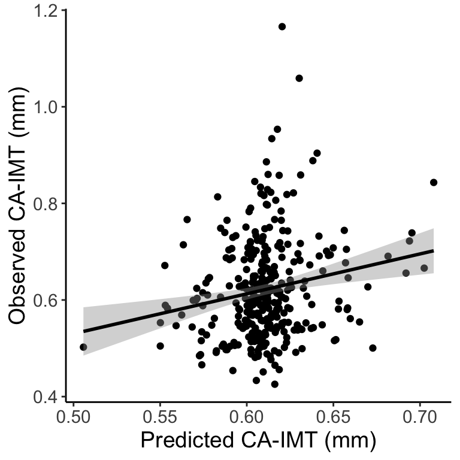

```r
ggplot(imt, aes(x = predicted, y = observed)) + geom_point() +
  geom_smooth(method = lm, colour = 'black') + theme_classic() +
  labs(x = "Predicted CA-IMT (mm)", y = "Observed CA-IMT (mm)") +
  theme(text = element_text(size = 14))
```

Compute BF as in (https://richarddmorey.github.io/BayesFactor/#lincor):

```r
bf = correlationBF(y = imt$observed, x = imt$predicted)
bf
```

```
## Bayes factor analysis
## --------------
## [1] Alt., r=0.333 : 45.70427 ±0%
##
## Against denominator:
##   Null, rho = 0
## ---
## Bayes factor type: BFcorrelation, Jeffreys-beta*
```

```r
samples = posterior(bf, iterations = 10000)
```

```
## Independent-candidate M-H acceptance rate: 96%
```

```r
summary(samples)
```

```
##
## Iterations = 1:10000
## Thinning interval = 1
## Number of chains = 1
## Sample size per chain = 10000
##
## 1. Empirical mean and standard deviation for each variable,
##    plus standard error of the mean:
##
##        Mean      SD  Naive SE Time-series SE
## rho  0.1829 0.05116 0.0005116      0.0005301
## zeta 0.1855 0.05308 0.0005308      0.0005498
##
## 2. Quantiles for each variable:
##
##         2.5%    25%    50%    75%  97.5%
## rho  0.08179 0.1476 0.1832 0.2181 0.2822
## zeta 0.08197 0.1487 0.1853 0.2216 0.2901
```

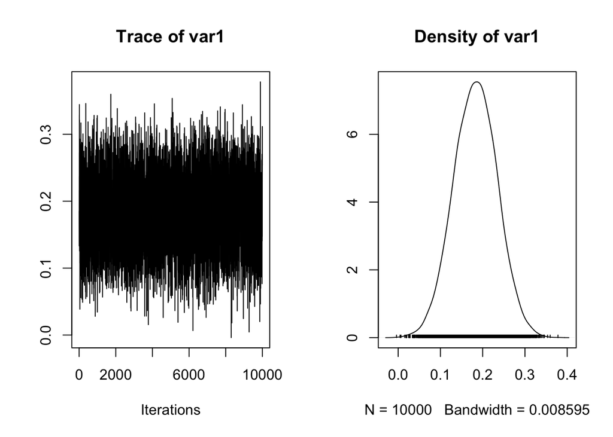

```r
plot(samples[,"rho"])
```

## IAPS - PINES

Load data:

```r
imt = read.csv('~/Box/@Predict_IMT/Generalizability/predicted_observed_pattern-PINES_contrasts-IAPS.csv')
colnames(imt) = c('predicted', 'observed')
```

Replicate correlation and scatterplot:

```r
cor.test(imt$predicted, imt$observed)
```

```
##
##  Pearson's product-moment correlation
##
## data:  imt$predicted and imt$observed
## t = 0.76993, df = 336, p-value = 0.4419
## alternative hypothesis: true correlation is not equal to 0
## 95 percent confidence interval:
##  -0.06500195  0.14798023
## sample estimates:
##        cor
## 0.04196587
```

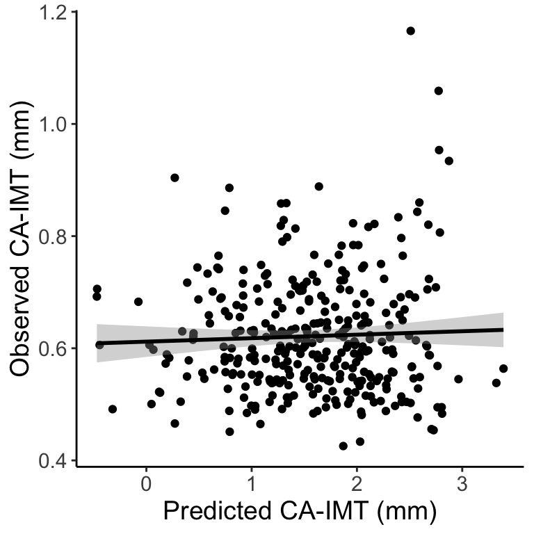

```r
ggplot(imt, aes(x = predicted, y = observed)) + geom_point() +
  geom_smooth(method = lm, colour = 'black') + theme_classic() +
  labs(x = "Predicted CA-IMT (mm)", y = "Observed CA-IMT (mm)") +
  theme(text = element_text(size = 14))
```

Compute BF as in (https://richarddmorey.github.io/BayesFactor/#lincor):

```r
bf = correlationBF(y = imt$observed, x = imt$predicted)
bf
```

```
## Bayes factor analysis
## --------------
## [1] Alt., r=0.333 : 0.1698622 ±0%
##
## Against denominator:
##   Null, rho = 0
## ---
## Bayes factor type: BFcorrelation, Jeffreys-beta*
```

```r
samples = posterior(bf, iterations = 10000)
```

```
## Independent-candidate M-H acceptance rate: 99%
```

```r
summary(samples)
```

```
##
## Iterations = 1:10000
## Thinning interval = 1
## Number of chains = 1
## Sample size per chain = 10000
##
## 1. Empirical mean and standard deviation for each variable,
##    plus standard error of the mean:
##
##         Mean      SD  Naive SE Time-series SE
## rho  0.03988 0.05445 0.0005445      0.0005445
## zeta 0.04002 0.05471 0.0005471      0.0005471
##
## 2. Quantiles for each variable:
##
##          2.5%      25%     50%     75%  97.5%
## rho  -0.06743 0.004056 0.03944 0.07680 0.1464
## zeta -0.06753 0.004056 0.03946 0.07695 0.1475
```

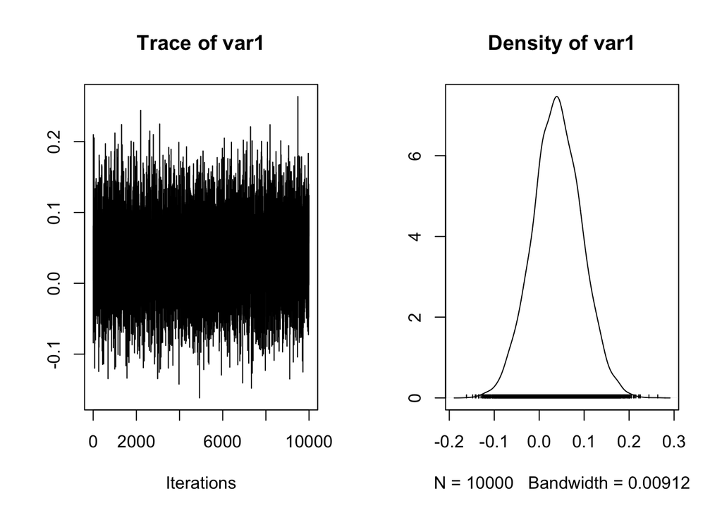

```r
plot(samples[,"rho"])
```

# New - BF for linear regressions (age, sex, CMR)

## OldFaces (PFA stimulus set)

### Does pattern predict above and beyond covariates?

Load data:

```r
imt = read.csv('~/Box/@Predict_IMT/Faces/OF/AllFaces/cmr/data_withCMR.csv')
```

Replicate regression:

```r
fit1 = lm(IMT_observed ~ age + sex + CMR, data = imt)
fit2 = lm(IMT_observed ~ age + sex + CMR + IMT_predicted, data = imt)
tab_model(fit1, fit2, show.std = T, show.ci = F, show.se = T, show.est = F)
```

|  | IMT observed |  |  | IMT observed |  |  |
| --- | --- | --- | --- | --- | --- | --- |
| Predictors | std. Beta | standardized std. Error | p | std. Beta | standardized std. Error | p |
| (Intercept) |  |  | **<0.001** |  |  | 0.122 |
| age | 0.51 | 0.04 | **<0.001** | 0.51 | 0.04 | **<0.001** |
| sex | -0.07 | 0.04 | 0.118 | -0.07 | 0.04 | 0.100 |
| CMR | 0.31 | 0.04 | **<0.001** | 0.30 | 0.04 | **<0.001** |
| IMT predicted |  |  |  | 0.03 | 0.04 | 0.378 |
| Observations | 427 |  |  | 427 |  |  |
| R<sup>2</sup> / adjusted R<sup>2</sup> | 0.404 / 0.400 |  |  | 0.405 / 0.399 |  |  |

Compute BF as in (https://richarddmorey.github.io/BayesFactor/#glm):

```r
full = lmBF(IMT_observed ~ age + sex + CMR + IMT_predicted, data = imt)
noBrain = lmBF(IMT_observed ~ age + sex + CMR, data = imt)
brainOnly = lmBF(IMT_observed ~ IMT_predicted, data = imt)
allBFs = c(full, noBrain, brainOnly)
allBFs
```

```
## Bayes factor analysis
## --------------
## [1] age + sex + CMR + IMT_predicted : 1.145333e+43 ±0%
## [2] age + sex + CMR                 : 7.630401e+43 ±0%
## [3] IMT_predicted                   : 4.586618     ±0%
##
## Against denominator:
##   Intercept only
## ---
## Bayes factor type: BFlinearModel, JZS
```

```r
full / noBrain
```

```
## Bayes factor analysis
## --------------
## [1] age + sex + CMR + IMT_predicted : 0.1501013 ±0%
##
## Against denominator:
##   IMT_observed ~ age + sex + CMR
## ---
## Bayes factor type: BFlinearModel, JZS
```

### Does age, sex, or CMR modify prediction?

### AGE

Replicate regression:

```r
imt$ageint = scale(imt$age, scale = F)*scale(imt$IMT_predicted, scale = F)
fit1 = lm(IMT_observed ~ age + IMT_predicted, data = imt)
fit2 = lm(IMT_observed ~ age + IMT_predicted + ageint, data = imt)
tab_model(fit1, fit2, show.std = T, show.ci = F, show.se = T, show.est = F)
```

|  | IMT observed |  |  | IMT observed |  |  |
| --- | --- | --- | --- | --- | --- | --- |
| Predictors | std. Beta | standardized std. Error | p | std. Beta | standardized std. Error | p |
| (Intercept) |  |  | 0.771 |  |  | 0.632 |
| age | 0.53 | 0.04 | **<0.001** | 0.53 | 0.04 | **<0.001** |
| IMT predicted | 0.10 | 0.04 | **0.019** | 0.10 | 0.04 | **0.013** |
| ageint |  |  |  | 0.04 | 0.04 | 0.340 |
| Observations | 427 |  |  | 427 |  |  |
| R<sup>2</sup> / adjusted R<sup>2</sup> | 0.299 / 0.296 |  |  | 0.301 / 0.296 |  |  |

Compute BF as in (https://richarddmorey.github.io/BayesFactor/#glm):

```r
full = lmBF(IMT_observed ~ age + IMT_predicted + ageint, data = imt)
noInteraction = lmBF(IMT_observed ~ age + IMT_predicted, data = imt)
allBFs = c(full, noInteraction)
allBFs
```

```
## Bayes factor analysis
## --------------
## [1] age + IMT_predicted + ageint : 2.602804e+29 ±0%
## [2] age + IMT_predicted          : 1.591056e+30 ±0%
##
## Against denominator:
##   Intercept only
## ---
## Bayes factor type: BFlinearModel, JZS
```

```r
full / noInteraction
```

```
## Bayes factor analysis
## --------------
## [1] age + IMT_predicted + ageint : 0.1635897 ±0%
##
## Against denominator:
##   IMT_observed ~ age + IMT_predicted
## ---
## Bayes factor type: BFlinearModel, JZS
```

### SEX

Replicate regression:

```r
imt$sexint = scale(imt$sex, scale = F)*scale(imt$IMT_predicted, scale = F)
fit1 = lm(IMT_observed ~ sex + IMT_predicted, data = imt)
fit2 = lm(IMT_observed ~ sex + IMT_predicted + sexint, data = imt)
tab_model(fit1, fit2, show.std = T, show.ci = F, show.se = T, show.est = F)
```

|  | IMT observed |  |  | IMT observed |  |  |
| --- | --- | --- | --- | --- | --- | --- |
| Predictors | std. Beta | standardized std. Error | p | std. Beta | standardized std. Error | p |
| (Intercept) |  |  | 0.117 |  |  | 0.174 |
| sex | -0.12 | 0.05 | **0.012** | -0.12 | 0.05 | **0.012** |
| IMT predicted | 0.14 | 0.05 | **0.005** | 0.15 | 0.05 | **0.003** |
| sexint |  |  |  | 0.06 | 0.05 | 0.187 |
| Observations | 427 |  |  | 427 |  |  |
| R<sup>2</sup> / adjusted R<sup>2</sup> | 0.033 / 0.028 |  |  | 0.036 / 0.030 |  |  |

Compute BF as in (https://richarddmorey.github.io/BayesFactor/#glm):

```r
full = lmBF(IMT_observed ~ sex + IMT_predicted + sexint, data = imt)
noInteraction = lmBF(IMT_observed ~ sex + IMT_predicted, data = imt)
allBFs = c(full, noInteraction)
allBFs
```

```
## Bayes factor analysis
## --------------
## [1] sex + IMT_predicted + sexint : 6.317825 ±0%
## [2] sex + IMT_predicted          : 14.66293 ±0.01%
##
## Against denominator:
##   Intercept only
## ---
## Bayes factor type: BFlinearModel, JZS
```

```r
full / noInteraction
```

```
## Bayes factor analysis
## --------------
## [1] sex + IMT_predicted + sexint : 0.4308706 ±0.01%
##
## Against denominator:
##   IMT_observed ~ sex + IMT_predicted
## ---
## Bayes factor type: BFlinearModel, JZS
```

### CMR

Replicate regression:

```r
imt$cmrint = scale(imt$CMR, scale = F)*scale(imt$IMT_predicted, scale = F)
fit1 = lm(IMT_observed ~ CMR + IMT_predicted, data = imt)
fit2 = lm(IMT_observed ~ CMR + IMT_predicted + cmrint, data = imt)
tab_model(fit1, fit2, show.std = T, show.ci = F, show.se = T, show.est = F)
```

|  | IMT observed |  |  | IMT observed |  |  |
| --- | --- | --- | --- | --- | --- | --- |
| Predictors | std. Beta | standardized std. Error | p | std. Beta | standardized std. Error | p |
| (Intercept) |  |  | **0.002** |  |  | **0.002** |
| CMR | 0.38 | 0.05 | **<0.001** | 0.39 | 0.05 | **<0.001** |
| IMT predicted | 0.05 | 0.05 | 0.261 | 0.05 | 0.05 | 0.282 |
| cmrint |  |  |  | -0.02 | 0.05 | 0.725 |
| Observations | 427 |  |  | 427 |  |  |
| R<sup>2</sup> / adjusted R<sup>2</sup> | 0.158 / 0.154 |  |  | 0.159 / 0.153 |  |  |

Compute BF as in (https://richarddmorey.github.io/BayesFactor/#glm):

```r
full = lmBF(IMT_observed ~ CMR + IMT_predicted + cmrint, data = imt)
noInteraction = lmBF(IMT_observed ~ CMR + IMT_predicted, data = imt)
allBFs = c(full, noInteraction)
allBFs
```

```
## Bayes factor analysis
## --------------
## [1] CMR + IMT_predicted + cmrint : 6.218178e+12 ±0%
## [2] CMR + IMT_predicted          : 4.242885e+13 ±0%
##
## Against denominator:
##   Intercept only
## ---
## Bayes factor type: BFlinearModel, JZS
```

```r
full / noInteraction
```

```
## Bayes factor analysis
## --------------
## [1] CMR + IMT_predicted + cmrint : 0.1465554 ±0%
##
## Against denominator:
##   IMT_observed ~ CMR + IMT_predicted
## ---
## Bayes factor type: BFlinearModel, JZS
```

## IAPS

### Does pattern predict above and beyond covariates?

Load data:

```r
imt = read.csv('~/Box/@Predict_IMT/IAPS/cmr/data_withCMR.csv')
```

Replicate regression:

```r
fit1 = lm(IMT_observed ~ age + sex + CMR, data = imt)
fit2 = lm(IMT_observed ~ age + sex + CMR + IMT_predicted, data = imt)
tab_model(fit1, fit2, show.std = T, show.ci = F, show.se = T, show.est = F)
```

|  | IMT observed |  |  | IMT observed |  |  |
| --- | --- | --- | --- | --- | --- | --- |
| Predictors | std. Beta | standardized std. Error | p | std. Beta | standardized std. Error | p |
| (Intercept) |  |  | **<0.001** |  |  | 0.335 |
| age | 0.46 | 0.05 | **<0.001** | 0.46 | 0.04 | **<0.001** |
| sex | -0.04 | 0.05 | 0.450 | -0.05 | 0.05 | 0.336 |
| CMR | 0.28 | 0.05 | **<0.001** | 0.28 | 0.05 | **<0.001** |
| IMT predicted |  |  |  | 0.18 | 0.04 | **<0.001** |
| Observations | 338 |  |  | 338 |  |  |
| R<sup>2</sup> / adjusted R<sup>2</sup> | 0.337 / 0.332 |  |  | 0.370 / 0.362 |  |  |

Compute BF as in (https://richarddmorey.github.io/BayesFactor/#glm):

```r
full = lmBF(IMT_observed ~ age + sex + CMR + IMT_predicted, data = imt)
noBrain = lmBF(IMT_observed ~ age + sex + CMR, data = imt)
brainOnly = lmBF(IMT_observed ~ IMT_predicted, data = imt)
allBFs = c(full, noBrain, brainOnly)
allBFs
```

```
## Bayes factor analysis
## --------------
## [1] age + sex + CMR + IMT_predicted : 1.393538e+29 ±0%
## [2] age + sex + CMR                 : 3.138549e+26 ±0%
## [3] IMT_predicted                   : 39.73002     ±0%
##
## Against denominator:
##   Intercept only
## ---
## Bayes factor type: BFlinearModel, JZS
```

```r
full / noBrain
```

```
## Bayes factor analysis
## --------------
## [1] age + sex + CMR + IMT_predicted : 444.0071 ±0%
##
## Against denominator:
##   IMT_observed ~ age + sex + CMR
## ---
## Bayes factor type: BFlinearModel, JZS
```

### Does age, sex, or CMR modify prediction?

### AGE

Replicate regression:

```r
imt$ageint = scale(imt$age, scale = F)*scale(imt$IMT_predicted, scale = F)
fit1 = lm(IMT_observed ~ age + IMT_predicted, data = imt)
fit2 = lm(IMT_observed ~ age + IMT_predicted + ageint, data = imt)
tab_model(fit1, fit2, show.std = T, show.ci = F, show.se = T, show.est = F)
```

|  | IMT observed |  |  | IMT observed |  |  |
| --- | --- | --- | --- | --- | --- | --- |
| Predictors | std. Beta | standardized std. Error | p | std. Beta | standardized std. Error | p |
| (Intercept) |  |  | 0.320 |  |  | 0.253 |
| age | 0.50 | 0.05 | **<0.001** | 0.49 | 0.05 | **<0.001** |
| IMT predicted | 0.17 | 0.05 | **<0.001** | 0.18 | 0.05 | **<0.001** |
| ageint |  |  |  | 0.07 | 0.05 | 0.155 |
| Observations | 338 |  |  | 338 |  |  |
| R<sup>2</sup> / adjusted R<sup>2</sup> | 0.280 / 0.276 |  |  | 0.284 / 0.278 |  |  |

Compute BF as in (https://richarddmorey.github.io/BayesFactor/#glm):

```r
full = lmBF(IMT_observed ~ age + IMT_predicted + ageint, data = imt)
noInteraction = lmBF(IMT_observed ~ age + IMT_predicted, data = imt)
allBFs = c(full, noInteraction)
allBFs
```

```
## Bayes factor analysis
## --------------
## [1] age + IMT_predicted + ageint : 1.074245e+21 ±0%
## [2] age + IMT_predicted          : 3.283582e+21 ±0%
##
## Against denominator:
##   Intercept only
## ---
## Bayes factor type: BFlinearModel, JZS
```

```r
full / noInteraction
```

```
## Bayes factor analysis
## --------------
## [1] age + IMT_predicted + ageint : 0.3271563 ±0%
##
## Against denominator:
##   IMT_observed ~ age + IMT_predicted
## ---
## Bayes factor type: BFlinearModel, JZS
```

### SEX

Replicate regression:

```r
imt$sexint = scale(imt$sex, scale = F)*scale(imt$IMT_predicted, scale = F)
fit1 = lm(IMT_observed ~ sex + IMT_predicted, data = imt)
fit2 = lm(IMT_observed ~ sex + IMT_predicted + sexint, data = imt)
tab_model(fit1, fit2, show.std = T, show.ci = F, show.se = T, show.est = F)
```

|  | IMT observed |  |  | IMT observed |  |  |
| --- | --- | --- | --- | --- | --- | --- |
| Predictors | std. Beta | standardized std. Error | p | std. Beta | standardized std. Error | p |
| (Intercept) |  |  | 0.310 |  |  | 0.279 |
| sex | -0.12 | 0.05 | **0.029** | -0.12 | 0.05 | **0.030** |
| IMT predicted | 0.19 | 0.05 | **<0.001** | 0.19 | 0.05 | **<0.001** |
| sexint |  |  |  | -0.05 | 0.05 | 0.384 |
| Observations | 338 |  |  | 338 |  |  |
| R<sup>2</sup> / adjusted R<sup>2</sup> | 0.049 / 0.043 |  |  | 0.051 / 0.042 |  |  |

Compute BF as in (https://richarddmorey.github.io/BayesFactor/#glm):

```r
full = lmBF(IMT_observed ~ sex + IMT_predicted + sexint, data = imt)
noInteraction = lmBF(IMT_observed ~ sex + IMT_predicted, data = imt)
allBFs = c(full, noInteraction)
allBFs
```

```
## Bayes factor analysis
## --------------
## [1] sex + IMT_predicted + sexint : 18.51962 ±0%
## [2] sex + IMT_predicted          : 64.40689 ±0%
##
## Against denominator:
##   Intercept only
## ---
## Bayes factor type: BFlinearModel, JZS
```

```r
full / noInteraction
```

```
## Bayes factor analysis
## --------------
## [1] sex + IMT_predicted + sexint : 0.2875409 ±0%
##
## Against denominator:
##   IMT_observed ~ sex + IMT_predicted
## ---
## Bayes factor type: BFlinearModel, JZS
```

### CMR

Replicate regression:

```r
imt$cmrint = scale(imt$CMR, scale = F)*scale(imt$IMT_predicted, scale = F)
fit1 = lm(IMT_observed ~ CMR + IMT_predicted, data = imt)
fit2 = lm(IMT_observed ~ CMR + IMT_predicted + cmrint, data = imt)
tab_model(fit1, fit2, show.std = T, show.ci = F, show.se = T, show.est = F)
```

|  | IMT observed |  |  | IMT observed |  |  |
| --- | --- | --- | --- | --- | --- | --- |
| Predictors | std. Beta | standardized std. Error | p | std. Beta | standardized std. Error | p |
| (Intercept) |  |  | 0.426 |  |  | 0.968 |
| CMR | 0.37 | 0.05 | **<0.001** | 0.38 | 0.05 | **<0.001** |
| IMT predicted | 0.20 | 0.05 | **<0.001** | 0.24 | 0.05 | **<0.001** |
| cmrint |  |  |  | 0.10 | 0.05 | 0.077 |
| Observations | 338 |  |  | 338 |  |  |
| R<sup>2</sup> / adjusted R<sup>2</sup> | 0.173 / 0.168 |  |  | 0.181 / 0.174 |  |  |

Compute BF as in (https://richarddmorey.github.io/BayesFactor/#glm):

```r
full = lmBF(IMT_observed ~ CMR + IMT_predicted + cmrint, data = imt)
noInteraction = lmBF(IMT_observed ~ CMR + IMT_predicted, data = imt)
allBFs = c(full, noInteraction)
allBFs
```

```
## Bayes factor analysis
## --------------
## [1] CMR + IMT_predicted + cmrint : 316705751794 ±0%
## [2] CMR + IMT_predicted          : 462245717650 ±0%
##
## Against denominator:
##   Intercept only
## ---
## Bayes factor type: BFlinearModel, JZS
```

```r
full / noInteraction
```

```
## Bayes factor analysis
## --------------
## [1] CMR + IMT_predicted + cmrint : 0.6851459 ±0%
##
## Against denominator:
##   IMT_observed ~ CMR + IMT_predicted
## ---
## Bayes factor type: BFlinearModel, JZS
```